# gllvmprime: fit a GLLVM model

Guillaume Blanc

2023-01-30

This document showcases how to fit a GLLVM model to a toy dataset using the package `gllvmprime`. This dataset has a matrix of responses `Y` with $n=1000$ observations on $p=20$ responses, the first $10$ of which are (conditional) Gaussian and the last $10$ are (conditional) Bernoulli. What’s more, it has covariate matrix `X`, which includes an intercept as a column of $1$.

Fitting the dataset consists in calling the `gllvmprime` function. The necessary parameters to give are: a matrix of responses `Y`, the number of latent variables, i.e. the dimensions of the latent space $q$ (defaults to 2), and the type of responses given by a vector of the names of their conditional distribution, `family`. The `family` argument admits either a string if the responses are all of the same type, or, more generally, a $p$-dimensional vector of strings corresponding to the types of random variables. The types of conditional distribution currently implemented are `poisson`, `bernoulli`, and `gaussian`. Other noteworthy arguments of the `gllvmprime` function are: `X`, a matrix of covariate; `intercept`: a boolean variable which, if set to `intercept=TRUE`, will concatenate a column of ones to the matrix of covariates `X` (and create it if it does not exist), except if `X` already contains an intercept column, in which case the `intercept` argument is ignored; `maxit`: the maximum number of iterations; `alpha`: a learning rate, which defaults to `alpha=1` , and which controls the variance of the iteration values.

## Fit a GLLVM model with mixed responses

```r
library(gllvmprime)

# The data is loaded
data <- readRDS("../data/example_1.rds")

# The families are specified.
family <- c(rep("gaussian", 10), rep("binomial", 10))

set.seed(213)
fit <- gllvmprime(data$Y, q=2, X=data$X, family=family)
```

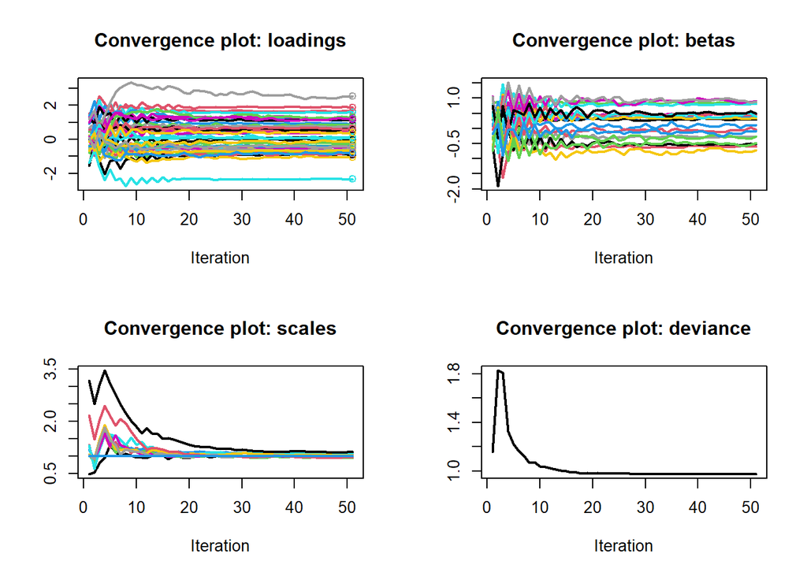

```r
plot(fit)
```

For best results, fitting a model using `gllvmprime`should be iterative: after the first fit, the user should use the visual diagnostic tools to assess the convergence, and, if necessary, update the fit using the `update` function, which is discussed below. This process is iterated until the user is satisfied with the fit. On the one hand, this procedure requires some work on the user’s side; on the other, it provides them with the reassurance that the algorithm has properly converged.

To improve on the result, let us use the `update` function, to update the fit. This function admits the same arguments as `gllvmprime`, and will use as default the values of the arguments right before the end of the last call of either `gllvmprime` or `update`. That is, it will start the fitting process where it was just left off.

```r
fit <- update(fit)
fit <- update(fit, alpha=fit$controls$alpha)
```

But alpha could have been decreased or increased, depending on the graphs obtained in the first run. Let’s continue with the final value of `alpha` of the previous fit, which is the default behavior of `update`. For curiosity, it is accessed in `fit$controls$alpha` and has value `alpha=`0.457. Let’s increase the iterations to 100 using `maxit=100` to obtain our final estimate.

```r
fit <- update(fit, maxit=100, alpha=fit$controls$alpha)
```

We now again plot the new fit:

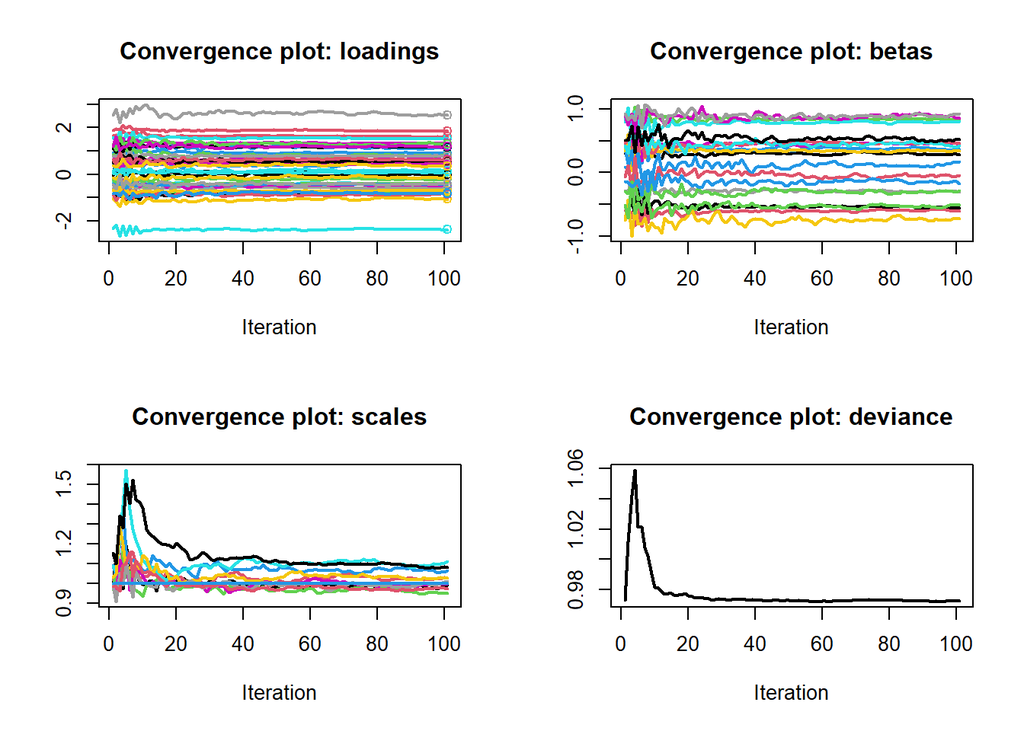

```r
plot(fit)
```

The convergence is good: there is no obvious trends in the convergence plots and the deviance plot seems to have stabilized. The scale parameters still showcase a bit of variance, but this does not affect the loadings and fixed coefficients much, if at all. Updating the fit once more using `fit <- update(fit, alpha=fit$controls$alpha/2)` will provide good results. Note that the final value of the parameter reported by the algorithm is computed as the average of the last 20 iteration values, which further reduces the noise in the final estimate.

## Displaying the results

The parameters values are available in `fit$parameters` and can be visualized by printing the `fit` object. The `print` method accepts an extra parameter, `n`, which takes the default value `n=10` and which limits the printing of the parameter values to the first $10$ lines. Since we have $20$ responses, we set this value to `n=20` in order to see all parameters.

```r
print(fit, n=20)
```

```
#> Fitted GLLVM model:
#> -------------------
#> Loadings:
#> # A tibble: 20 × 1
#>      A[,1]    [,2]
#>      <dbl>   <dbl>
#>  1  0.0939  0.0687
#>  2  1.61    1.33
#>  3 -0.783  -0.700
#>  4  0.901   0.776
#>  5  1.53    1.17
#>  6  0.626   0.534
#>  7 -0.448  -0.403
#>  8 -0.571  -0.439
#>  9 -0.824  -2.37
```

[output cut: 46 more lines]